# SVA/ComBat

Joyce Hsiao

2015-11-30

## Goal

Apply SVA package for batch effect correction.

## Summary

In our batch-effect correction framework, we corrected within replicate (plate) bias between cells using our information on ERCC percentage, and then remove between-plate bias in molecule counts using a linear mixed model framework.

Majority of the work done in batch-effect correction literature focues on removing batch-to-batch differences in gene expression distributions. The original SVA ([Leek et al., 2012][Leek2014]) work was designed to compute one or more variates that estimate the batch-to-batch differences in gene expression; they refer to these variates as surrogate variables. The SVA analysis is typically performed in an unsupervised manner using factor analysis to estimate one or more variates of batch-to-batch differences, but can also be applied to estimate surrogate variables based on control genes. RUVseq is similar to SVA but it extends one step further to directly model and remove unwanted variation estimated from control gene expression data in endogeneous gene expression data.

ComBat is another method that corrects for batch-to-batch differences in gene expresion levels. The method estimates per gene batch effect in an additive linear model and then pools per gene information together to compute a gene-wide batch-effect correction factor. The ComBat framework is similar to the limma framework, which was designed intially to tackle batch effect issues in microarray studies but has since then been extended to numerous RNAseq experiments.

In practice, we would like to obtain a batch correct data sets with the “corrected” gene expression measurements to compare experimental effects before and after batch correction. SVA computes continuous variable(s) that capture unwanted source(s) of variation - referred to as surrogate variable(s. The method, as described in the vignette, does not output a batch-corrected data set; instead, the surrogate variables are included in the design matrix when testing hypothesis of interest. They also gave an example of using surrogate variables in limma lmFit function.

RUVseq and comBat both output batch-effect corrected data set. However, RUVseq assumes that ERCC percentages are the same across replicates, and comBat is not designed for use with control spike-in genes.

## Set up

```r
library(sva)

library(knitr)
opts_knit$set(progress = TRUE, verbose = TRUE)
opts_chunk$set(message = FALSE, warning = FALSE, eval = TRUE,
               echo = TRUE)

source("../R/functions.R")
```

## Prepare data

Import filtered molecule count data.

```r
molecules_filter <- read.table("../data/molecules-filter.txt",
                               header = TRUE, sep = "\t",
                               stringsAsFactors = FALSE,
                               row.names = 1)
head(molecules_filter[1:2, 1:5])
```

```
##                 NA19098.r1.A01 NA19098.r1.A02 NA19098.r1.A04
## ENSG00000237683              1              0              3
## ENSG00000188976              3              3              2
##                 NA19098.r1.A05 NA19098.r1.A06
## ENSG00000237683              0              0
## ENSG00000188976              7              1
```

Select ERCC genes

```r
molecules_ercc <- molecules_filter[ grep("ERCC", rownames(molecules_filter)), ]
```

Import filtered molecule CPM ERCC data.

```r
molecules_cpm_ercc <- read.table("../data/molecules-cpm-ercc.txt",
                               header = TRUE, sep = "\t",
                               stringsAsFactors = FALSE,
                               row.names = 1)
head(molecules_cpm_ercc[1:2, 1:5])
```

```
##            NA19098.r1.A01 NA19098.r1.A02 NA19098.r1.A04 NA19098.r1.A05
## ERCC-00002       17.38058       17.15942       17.01307       17.20051
## ERCC-00003       13.54975       13.88749       13.68995       14.37320
##            NA19098.r1.A06
## ERCC-00002       16.94740
## ERCC-00003       12.94173
```

Import annotation information fo the filtered data

```r
annotation_filter <- read.table("../data/annotation-filter.txt",
                                header = TRUE, sep = "\t",
                                stringsAsFactors = FALSE)
head(annotation_filter)
```

```
##   individual replicate well      batch      sample_id
## 1    NA19098        r1  A01 NA19098.r1 NA19098.r1.A01
## 2    NA19098        r1  A02 NA19098.r1 NA19098.r1.A02
## 3    NA19098        r1  A04 NA19098.r1 NA19098.r1.A04
## 4    NA19098        r1  A05 NA19098.r1 NA19098.r1.A05
## 5    NA19098        r1  A06 NA19098.r1 NA19098.r1.A06
## 6    NA19098        r1  A07 NA19098.r1 NA19098.r1.A07
```

```r
stopifnot(NCOL(molecules_filter) == NROW(annotation_filter))
```

Import endogeneous gene molecule counts before applying mixed effect model.

```r
molecules_cpm_trans <- read.table("../data/molecules-cpm-trans.txt",
                               header = TRUE, sep = "\t",
                               stringsAsFactors = FALSE,
                               row.names = 1)
```

## SVA

Here I run over SVA workflow. The surrogate variables are not helpful in our analyses, as they are computed to remove bias in estimate mean differences between the samples. We are interested in comparing differences in variations between samples.

Define a control variable for ERCC genes.

```r
controls <- rownames(molecules_filter) %in% rownames(molecules_filter)[grep("ERCC", rownames(molecules_filter))]
```

Define design matrices

```r
# Under alternative hypothesis, excluding batch effect
mod1 <- model.matrix(~individual,
            data = annotation_filter)

# Udner null hypothesis, excluding batch effect
mod0 <- cbind(mod1[,1])
```

Perform unsupervised SVA, default option.

```r
svseq <- svaseq(as.matrix(molecules_filter[grep("ERCC", rownames(molecules_filter), invert = TRUE), ]),
            mod1, mod0, n.sv=1)$sv
```

```
## Number of significant surrogate variables is:  1
## Iteration (out of 5 ):1  2  3  4  5
```

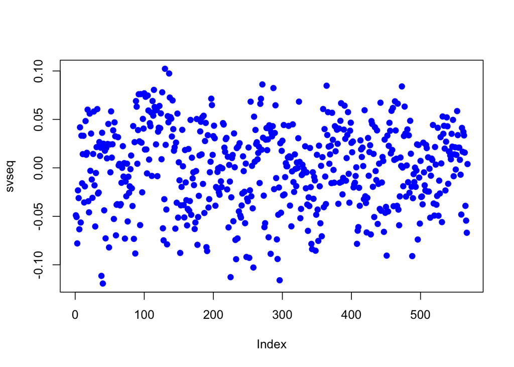

```r
plot(svseq, pch=19, col="blue")
```

Perform supervised SVA.

```r
sup_svseq <- svaseq(molecules_filter,
                    mod1, mod0, controls=controls, n.sv=1)$sv
```

```
## sva warning: controls provided so supervised sva is being performed.
## Number of significant surrogate variables is:  1
```

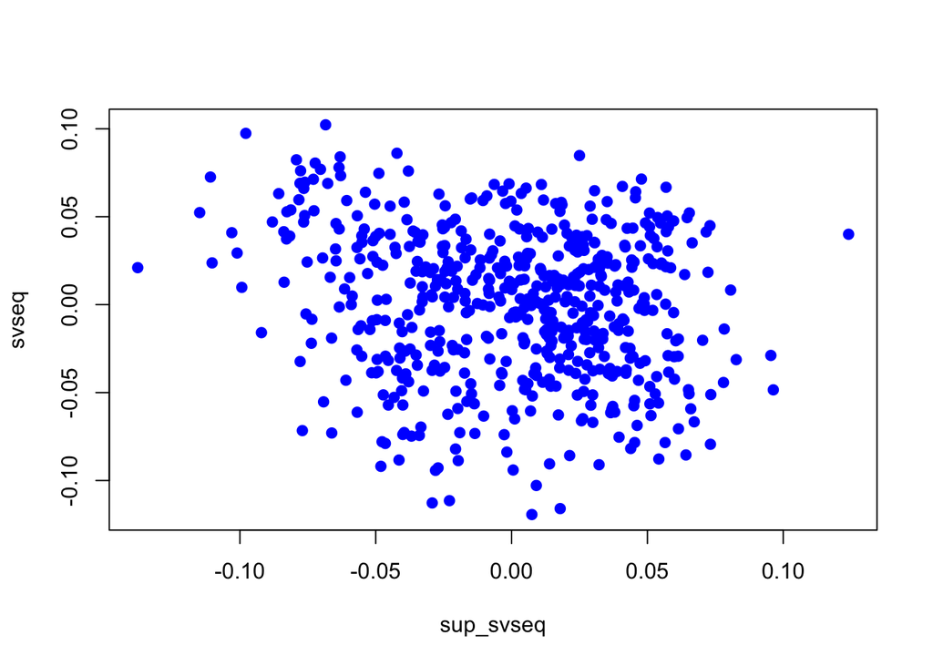

```r
plot(sup_svseq, svseq, pch=19, col="blue")
```

## comBat

```r
batch <- annotation_filter$batch

modcombat <- model.matrix(~1, data = annotation_filter)

combat_edata <- ComBat(dat = molecules_cpm_trans, batch = batch,
                       mod = modcombat, par.prior=TRUE, prior.plots=FALSE)
```

```
## Found 8 batches
## Adjusting for 0 covariate(s) or covariate level(s)
## Standardizing Data across genes
## Fitting L/S model and finding priors
## Finding parametric adjustments
## Adjusting the Data
```

```r
dim(combat_edata)
```

```
## [1] 10564   568
```

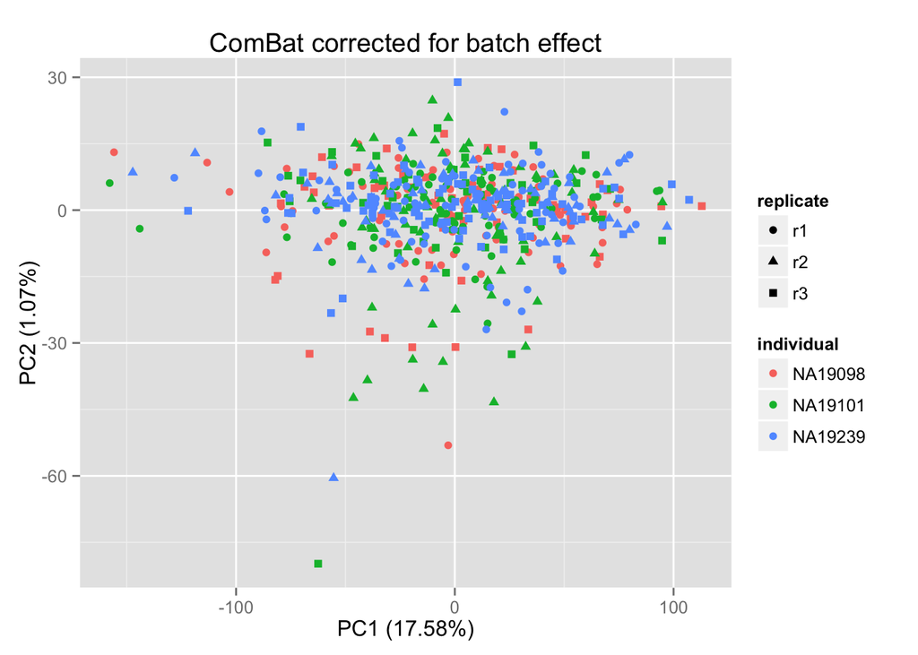

```r
combat_pca <- run_pca(combat_edata)

plot_pca(x = combat_pca$PCs,
         explained = combat_pca$explained,
         metadata = annotation_filter,
         color = "individual",
         shape = "replicate") +
    labs(title = "ComBat corrected for batch effect")
```